# Assignment 2

Molly F-F & Brittany O

2024-10-01

```r
library(tidyverse)
library(gtrendsR)
library(censusapi)
library(dplyr)
```

Link to GitHub repository: https://github.com/bnowen/FischFriedman-Owen-a2

# Pulling from APIs

Our first data source is the Google Trends API. Suppose we are interested in the search trends for crime and loans in Illinois in the year 2020. We could find this using the following code:

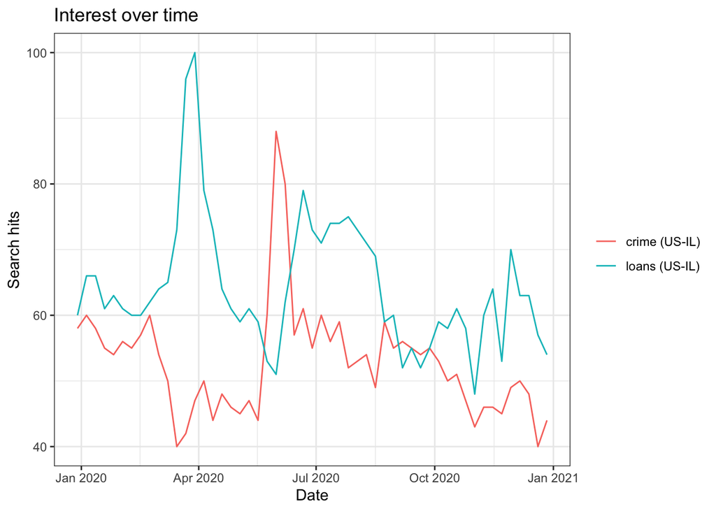

```r
res <- gtrends(c("crime", "loans"),
               geo = "US-IL",
               time = "2020-01-01 2020-12-31",
               low_search_volume = TRUE)
plot(res)
```

Answer the following questions for the keywords “crime” and “loans”.

• Find the mean, median and variance of the search hits for the keywords:

```r
head(res$interest_over_time)
```

```
##         date hits keyword   geo                  time gprop category
## 1 2019-12-29   58   crime US-IL 2020-01-01 2020-12-31   web        0
## 2 2020-01-05   60   crime US-IL 2020-01-01 2020-12-31   web        0
## 3 2020-01-12   58   crime US-IL 2020-01-01 2020-12-31   web        0
## 4 2020-01-19   55   crime US-IL 2020-01-01 2020-12-31   web        0
## 5 2020-01-26   54   crime US-IL 2020-01-01 2020-12-31   web        0
## 6 2020-02-02   56   crime US-IL 2020-01-01 2020-12-31   web        0
```

```r
res_time <- as_tibble(res$interest_over_time)
glimpse(res_time)
```

```
## Rows: 106
## Columns: 7
## $ date     <dttm> 2019-12-29, 2020-01-05, 2020-01-12, 2020-01-19, 2020-01-26, …
## $ hits     <int> 58, 60, 58, 55, 54, 56, 55, 57, 60, 54, 50, 40, 42, 47, 50, 4…
## $ keyword  <chr> "crime", "crime", "crime", "crime", "crime", "crime", "crime"…
## $ geo      <chr> "US-IL", "US-IL", "US-IL", "US-IL", "US-IL", "US-IL", "US-IL"…
## $ time     <chr> "2020-01-01 2020-12-31", "2020-01-01 2020-12-31", "2020-01-01…
## $ gprop    <chr> "web", "web", "web", "web", "web", "web", "web", "web", "web"…
## $ category <int> 0, 0, 0, 0, 0, 0, 0, 0, 0, 0, 0, 0, 0, 0, 0, 0, 0, 0, 0, 0, 0…
```

```r
res_time_w <- spread(res_time, key = keyword, value = hits)
head(res_time_w)
```

```
## # A tibble: 6 × 7
##   date                geo   time                  gprop category crime loans
##   <dttm>              <chr> <chr>                 <chr>    <int> <int> <int>
## 1 2019-12-29 00:00:00 US-IL 2020-01-01 2020-12-31 web          0    58    60
## 2 2020-01-05 00:00:00 US-IL 2020-01-01 2020-12-31 web          0    60    66
## 3 2020-01-12 00:00:00 US-IL 2020-01-01 2020-12-31 web          0    58    66
## 4 2020-01-19 00:00:00 US-IL 2020-01-01 2020-12-31 web          0    55    61
## 5 2020-01-26 00:00:00 US-IL 2020-01-01 2020-12-31 web          0    54    63
## 6 2020-02-02 00:00:00 US-IL 2020-01-01 2020-12-31 web          0    56    61
```

```r
mean_crime <- round(mean(res_time_w$crime),5)
median_crime <- median(res_time_w$crime)
var_crime <- round(var(res_time_w$crime),5)
mean_crime; median_crime; var_crime
```

```
## [1] 52.83019
```

```
## [1] 53
```

```
## [1] 71.72061
```

```r
mean_loans <- round(mean(res_time_w$loans),5)
median_loans <- median(res_time_w$loans)
var_loans <- round(var(res_time_w$loans),5)
mean_loans; median_loans; var_loans
```

```
## [1] 64.32075
```

```
## [1] 62
```

```
## [1] 99.76052
```

For the keyword “crime” in Illinois in 2020, the mean search volume is 52.83019, the median search volume is 53, and the variance is 71.72061.

For the keyword “loans” in Illinois in 2020, the mean search volume is 64.32075, the median search volume is 62, and the variance is 99.76052.

• Which cities (locations) have the highest search frequency for loans? Note that there might be multiple rows for each city if there were hits for both “crime” and “loans” in that city. It might be easier to answer this question if we had the search hits info for both search terms in two separate variables. That is, each row would represent a unique city.

```r
head(res$interest_by_city)
```

```
##           location hits keyword   geo gprop
## 1             Anna  100   crime US-IL   web
## 2       Streamwood   85   crime US-IL   web
## 3 East Saint Louis   85   crime US-IL   web
## 4  North Riverside   84   crime US-IL   web
## 5           Macomb   82   crime US-IL   web
## 6         Oak Lawn   82   crime US-IL   web
```

```r
res_city <- as_tibble(res$interest_by_city)
glimpse(res_city)
```

```
## Rows: 400
## Columns: 5
## $ location <chr> "Anna", "Streamwood", "East Saint Louis", "North Riverside", …
## $ hits     <int> 100, 85, 85, 84, 82, 82, 82, 80, 76, 71, 71, 71, 70, 68, 66, …
## $ keyword  <chr> "crime", "crime", "crime", "crime", "crime", "crime", "crime"…
## $ geo      <chr> "US-IL", "US-IL", "US-IL", "US-IL", "US-IL", "US-IL", "US-IL"…
## $ gprop    <chr> "web", "web", "web", "web", "web", "web", "web", "web", "web"…
```

```r
res_city_w <- spread(res_city, key = keyword, value = hits)
head(res_city_w)
```

```
## # A tibble: 6 × 5
##   location   geo   gprop crime loans
##   <chr>      <chr> <chr> <int> <int>
## 1 Alhambra   US-IL web      NA    NA
## 2 Allenville US-IL web      NA    NA
## 3 Alorton    US-IL web      NA    NA
## 4 Alto Pass  US-IL web      NA    NA
## 5 Altona     US-IL web      NA    NA
## 6 Ancona     US-IL web      NA    NA
```

```r
loansbycity <-  res_city_w %>%
  group_by(location) %>%
  summarize(loans = sum(loans)) %>%
  arrange(desc(loans))

na.omit(loansbycity)
```

```
## # A tibble: 38 × 2
##    location         loans
##    <chr>            <int>
##  1 Long Lake          100
##  2 East Saint Louis    84
##  3 Peotone             84
##  4 Rosemont            81
##  5 Ford Heights        78
##  6 Coal City           75
##  7 Dolton              72
##  8 Riverdale           72
##  9 Cahokia             70
## 10 Hazel Crest         70
## # ℹ 28 more rows
```

```r
top1 <- na.omit(loansbycity)[1,1]
top2 <- na.omit(loansbycity)[2,1]
top3 <- na.omit(loansbycity)[3,1]
top4 <- na.omit(loansbycity)[4,1]
top5 <- na.omit(loansbycity)[5,1]
```

The top 5 locations for ‘loans’ search hits are Long Lake, East Saint Louis, Peotone, Rosemont, and Ford Heights.

• Is there a relationship between the search intensities between the two keywords we used?

```r
res_both_w <- res_city_w %>%
  drop_na()
res_both_w
```

```
## # A tibble: 6 × 5
##   location         geo   gprop crime loans
##   <chr>            <chr> <chr> <int> <int>
## 1 Cahokia          US-IL web      71    70
## 2 Caseyville       US-IL web      64    64
## 3 East Saint Louis US-IL web      85    84
## 4 Paxton           US-IL web      70    60
## 5 Riverdale        US-IL web      57    72
## 6 Steger           US-IL web      71    55
```

### Repeat the above for keywords related to covid. Make sure you use multiple keywords like we did above. Try several different combinations and think carefully about words that might make sense within this context.

“Vaccine”[s], “test”[ing], “lockdown”, [social] “distancing”, and “mask”[s] are all words that were commonly used COVID-related media in 2020. “China” and the U.S. Presidential electoral candidates were prominent politically-oriented buzzwords during the same time period.

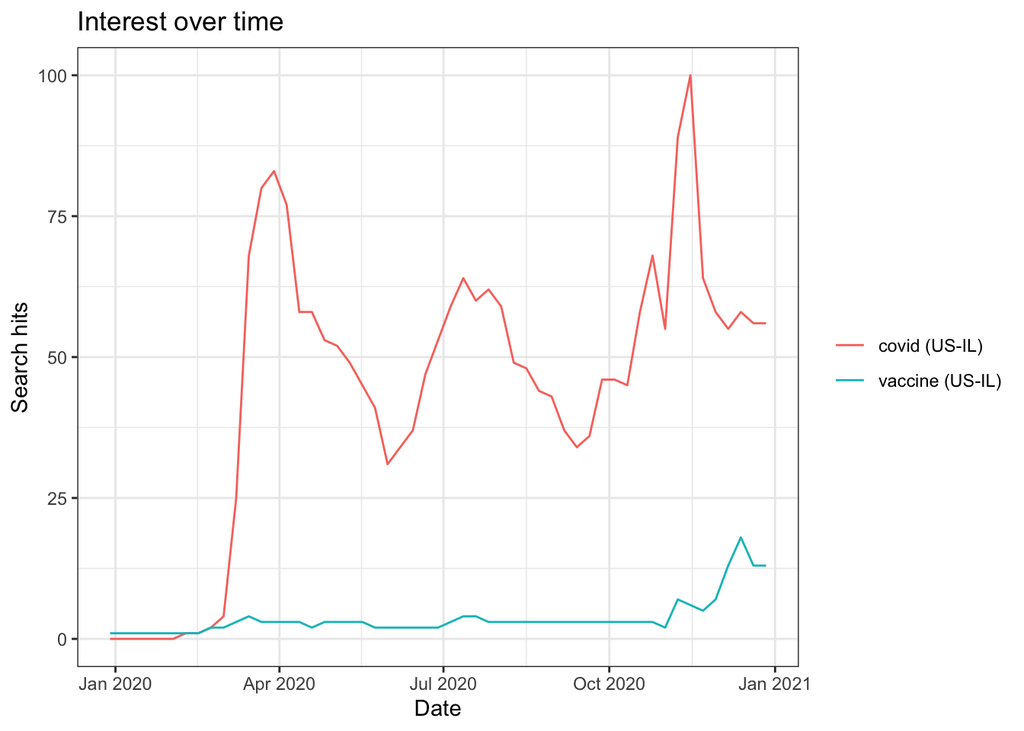

```r
covid.search1 <- gtrends(c("covid", "vaccine"),
geo = "US-IL",
time = "2020-01-01 2020-12-31",
low_search_volume = TRUE)
plot(covid.search1)
```

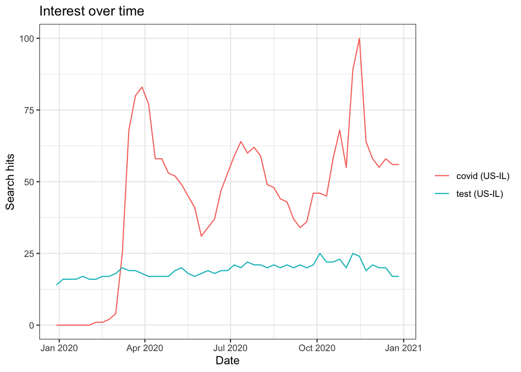

```r
covid.search2 <- gtrends(c("covid", "test"),
geo = "US-IL",
time = "2020-01-01 2020-12-31",
low_search_volume = TRUE)
plot(covid.search2)
```

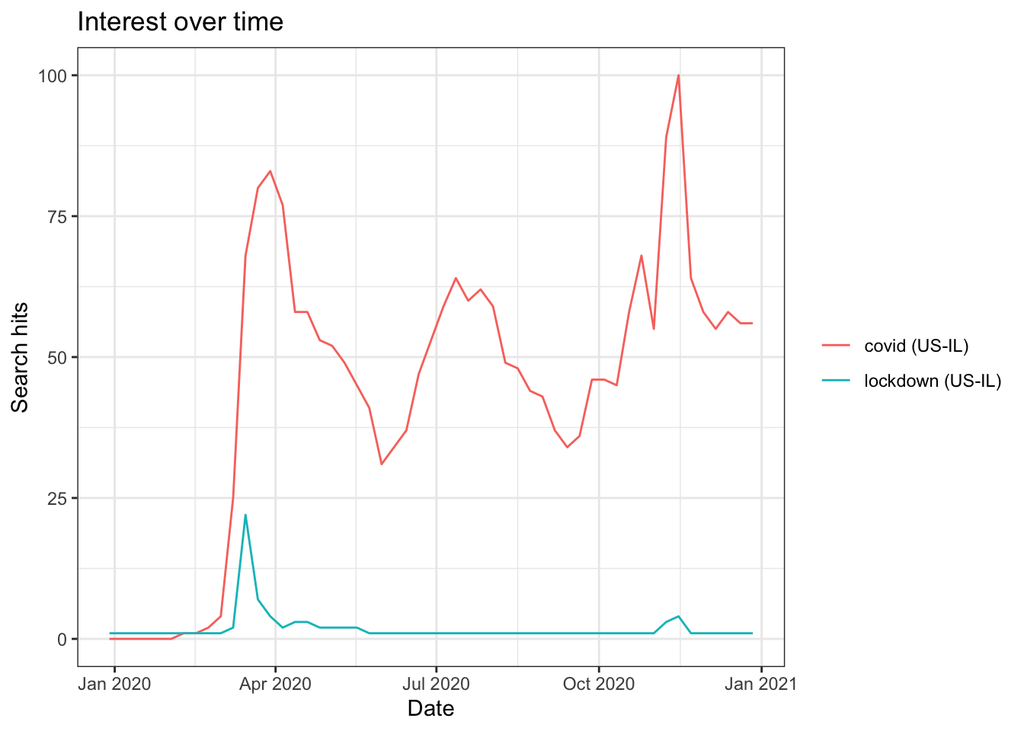

```r
covid.search3 <- gtrends(c("covid", "lockdown"),
geo = "US-IL",
time = "2020-01-01 2020-12-31",
low_search_volume = TRUE)
plot(covid.search3)
```

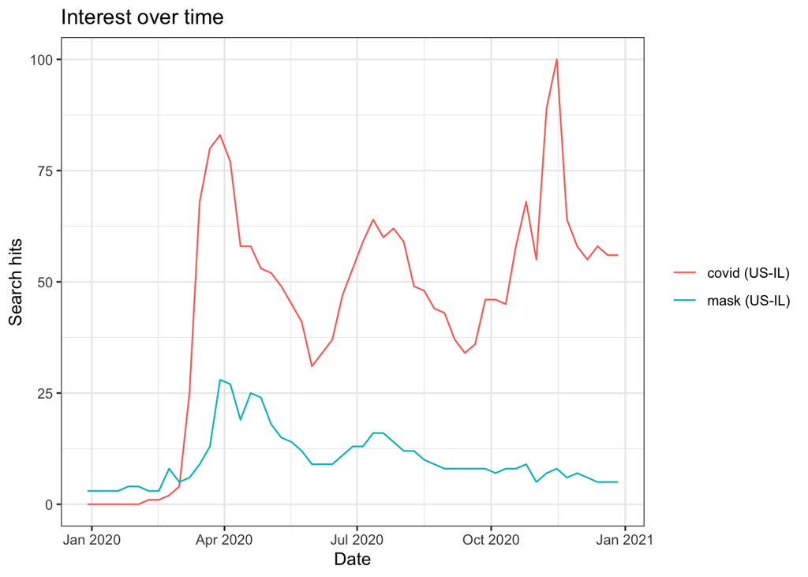

```r
covid.search4 <- gtrends(c("covid", "mask"),
geo = "US-IL",
time = "2020-01-01 2020-12-31",
low_search_volume = TRUE)
plot(covid.search4)
```

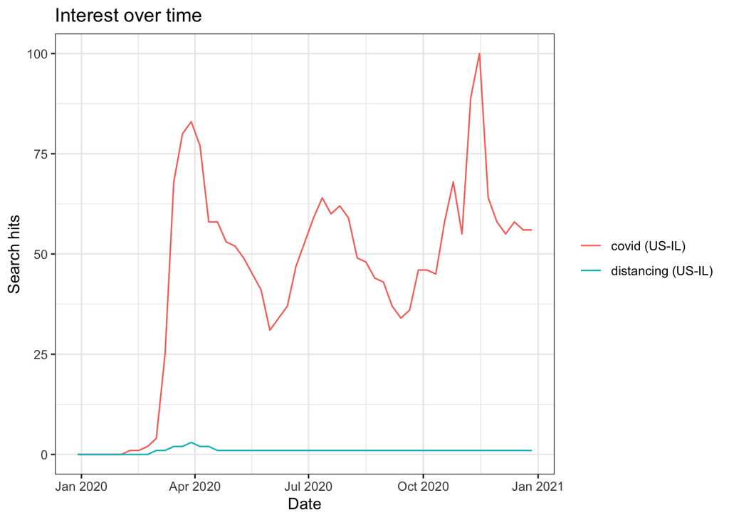

```r
covid.search5 <- gtrends(c("covid", "distancing"),
geo = "US-IL",
time = "2020-01-01 2020-12-31",
low_search_volume = TRUE)
plot(covid.search5)
```

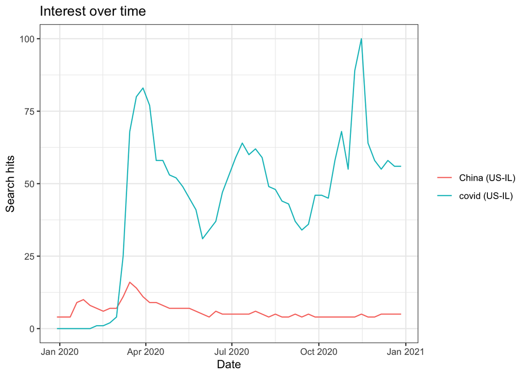

```r
covid.search6 <- gtrends(c("covid", "China"),
geo = "US-IL",
time = "2020-01-01 2020-12-31",
low_search_volume = TRUE)
plot(covid.search6)
```

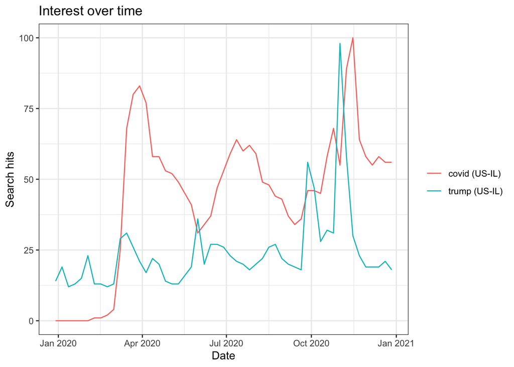

```r
covid.search7 <- gtrends(c("covid", "trump"),
geo = "US-IL",
time = "2020-01-01 2020-12-31",
low_search_volume = TRUE)
plot(covid.search7)
```

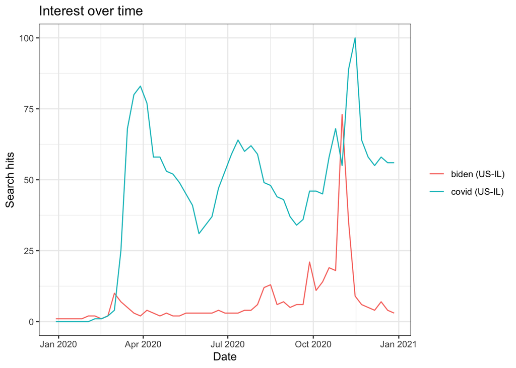

```r
covid.search8 <- gtrends(c("covid", "biden"),
geo = "US-IL",
time = "2020-01-01 2020-12-31",
low_search_volume = TRUE)
plot(covid.search8)
```

```r
rm(covid.search1,covid.search2, covid.search3, covid.search5, covid.search6, covid.search7, covid.search8)

head(covid.search4$interest_over_time)
```

```
##         date hits keyword   geo                  time gprop category
## 1 2019-12-29    0   covid US-IL 2020-01-01 2020-12-31   web        0
## 2 2020-01-05    0   covid US-IL 2020-01-01 2020-12-31   web        0
## 3 2020-01-12    0   covid US-IL 2020-01-01 2020-12-31   web        0
## 4 2020-01-19    0   covid US-IL 2020-01-01 2020-12-31   web        0
## 5 2020-01-26    0   covid US-IL 2020-01-01 2020-12-31   web        0
## 6 2020-02-02    0   covid US-IL 2020-01-01 2020-12-31   web        0
```

```r
covid_time <- as_tibble(covid.search4$interest_over_time)
glimpse(covid_time)
```

```
## Rows: 106
## Columns: 7
## $ date     <dttm> 2019-12-29, 2020-01-05, 2020-01-12, 2020-01-19, 2020-01-26, …
## $ hits     <chr> "0", "0", "0", "0", "0", "0", "<1", "<1", "2", "4", "25", "68…
## $ keyword  <chr> "covid", "covid", "covid", "covid", "covid", "covid", "covid"…
## $ geo      <chr> "US-IL", "US-IL", "US-IL", "US-IL", "US-IL", "US-IL", "US-IL"…
## $ time     <chr> "2020-01-01 2020-12-31", "2020-01-01 2020-12-31", "2020-01-01…
## $ gprop    <chr> "web", "web", "web", "web", "web", "web", "web", "web", "web"…
## $ category <int> 0, 0, 0, 0, 0, 0, 0, 0, 0, 0, 0, 0, 0, 0, 0, 0, 0, 0, 0, 0, 0…
```

```r
covid_time_w <- spread(covid_time, key = keyword, value = hits)
head(covid_time_w)
```

```
## # A tibble: 6 × 7
##   date                geo   time                  gprop category covid mask
##   <dttm>              <chr> <chr>                 <chr>    <int> <chr> <chr>
## 1 2019-12-29 00:00:00 US-IL 2020-01-01 2020-12-31 web          0 0     3
## 2 2020-01-05 00:00:00 US-IL 2020-01-01 2020-12-31 web          0 0     3
## 3 2020-01-12 00:00:00 US-IL 2020-01-01 2020-12-31 web          0 0     3
## 4 2020-01-19 00:00:00 US-IL 2020-01-01 2020-12-31 web          0 0     3
## 5 2020-01-26 00:00:00 US-IL 2020-01-01 2020-12-31 web          0 0     4
## 6 2020-02-02 00:00:00 US-IL 2020-01-01 2020-12-31 web          0 0     4
```

```r
glimpse(covid_time_w)
```

```
## Rows: 53
## Columns: 7
## $ date     <dttm> 2019-12-29, 2020-01-05, 2020-01-12, 2020-01-19, 2020-01-26, …
## $ geo      <chr> "US-IL", "US-IL", "US-IL", "US-IL", "US-IL", "US-IL", "US-IL"…
## $ time     <chr> "2020-01-01 2020-12-31", "2020-01-01 2020-12-31", "2020-01-01…
## $ gprop    <chr> "web", "web", "web", "web", "web", "web", "web", "web", "web"…
## $ category <int> 0, 0, 0, 0, 0, 0, 0, 0, 0, 0, 0, 0, 0, 0, 0, 0, 0, 0, 0, 0, 0…
## $ covid    <chr> "0", "0", "0", "0", "0", "0", "<1", "<1", "2", "4", "25", "68…
## $ mask     <chr> "3", "3", "3", "3", "4", "4", "3", "3", "8", "5", "6", "9", "…
```

```r
covid_time_w$covid <- as.numeric(covid_time_w$covid)
covid_time_w$mask <- as.numeric(covid_time_w$mask)
glimpse(covid_time_w)
```

```
## Rows: 53
## Columns: 7
## $ date     <dttm> 2019-12-29, 2020-01-05, 2020-01-12, 2020-01-19, 2020-01-26, …
## $ geo      <chr> "US-IL", "US-IL", "US-IL", "US-IL", "US-IL", "US-IL", "US-IL"…
## $ time     <chr> "2020-01-01 2020-12-31", "2020-01-01 2020-12-31", "2020-01-01…
## $ gprop    <chr> "web", "web", "web", "web", "web", "web", "web", "web", "web"…
## $ category <int> 0, 0, 0, 0, 0, 0, 0, 0, 0, 0, 0, 0, 0, 0, 0, 0, 0, 0, 0, 0, 0…
## $ covid    <dbl> 0, 0, 0, 0, 0, 0, NA, NA, 2, 4, 25, 68, 80, 83, 77, 58, 58, 5…
## $ mask     <dbl> 3, 3, 3, 3, 4, 4, 3, 3, 8, 5, 6, 9, 13, 28, 27, 19, 25, 24, 1…
```

```r
mean(covid_time_w$covid, na.rm = TRUE) #46
```

```
## [1] 46
```

```r
median(covid_time_w$covid, na.rm = TRUE) #49
```

```
## [1] 49
```

```r
var(covid_time_w$covid, na.rm = TRUE) #590.96
```

```
## [1] 590.96
```

```r
mean(covid_time_w$mask) #9.962264
```

```
## [1] 9.962264
```

```r
median(covid_time_w$mask) #8
```

```
## [1] 8
```

```r
var(covid_time_w$mask) #37.61393
```

```
## [1] 37.61393
```

```r
head(covid.search4$interest_by_city)
```

```
##          location hits keyword   geo gprop
## 1         Wheeler  100   covid US-IL   web
## 2 Clarendon Hills   87   covid US-IL   web
## 3          Geneva   86   covid US-IL   web
## 4        Bartelso   86   covid US-IL   web
## 5       Westfield   85   covid US-IL   web
## 6  Evergreen Park   85   covid US-IL   web
```

```r
covid_city <- as_tibble(covid.search4$interest_by_city)
glimpse(covid_city)
```

```
## Rows: 400
## Columns: 5
## $ location <chr> "Wheeler", "Clarendon Hills", "Geneva", "Bartelso", "Westfiel…
## $ hits     <int> 100, 87, 86, 86, 85, 85, 85, 85, 82, 81, 81, 81, 80, 80, 80, …
## $ keyword  <chr> "covid", "covid", "covid", "covid", "covid", "covid", "covid"…
## $ geo      <chr> "US-IL", "US-IL", "US-IL", "US-IL", "US-IL", "US-IL", "US-IL"…
## $ gprop    <chr> "web", "web", "web", "web", "web", "web", "web", "web", "web"…
```

```r
covid_city_w <- spread(covid_city, key = keyword, value = hits)
head(covid_city_w)
```

```
## # A tibble: 6 × 5
##   location   geo   gprop covid  mask
##   <chr>      <chr> <chr> <int> <int>
## 1 Albany     US-IL web      85    NA
## 2 Algonquin  US-IL web      65    NA
## 3 Allenville US-IL web      80    NA
## 4 Alton      US-IL web      NA    69
## 5 Altona     US-IL web      67    NA
## 6 Alvin      US-IL web      65    NA
```

```r
maskbycity <-  covid_city_w %>%
  group_by(location) %>%
  summarize(mask = sum(mask)) %>%
  arrange(desc(mask))

na.omit(maskbycity)
```

```
## # A tibble: 79 × 2
##    location       mask
##    <chr>         <int>
##  1 Minier          100
##  2 Waterman         86
##  3 Oakdale          85
##  4 Palos Heights    85
##  5 Philo            83
##  6 Keyesport        81
##  7 Lanark           78
##  8 Bushnell         77
##  9 Caledonia        76
## 10 Mokena           75
## # ℹ 69 more rows
```

```r
top1 <- na.omit(maskbycity)[1,1]
top2 <- na.omit(maskbycity)[2,1]
top3 <- na.omit(maskbycity)[3,1]
top4 <- na.omit(maskbycity)[4,1]
top5 <- na.omit(maskbycity)[5,1]
```

# Google Trends + ACS

Once you have a Census access key, save it as a text file, then read this key in the cs_key object. We will use this object in all following API queries.

```r
cs_key <- read_file("~/Downloads/census-key.txt")
```

In the following, we request basic socio-demographic information (population, median age, median household income, income per capita) for cities and villages in the state of Illinois.

```r
acs_il <- getCensus(name = "acs/acs5",
                    vintage = 2020,
                    vars = c("NAME",
                             "B01001_001E",
                             "B06002_001E",
                             "B19013_001E",
                             "B19301_001E"),
                    region = "place:*",
                    regionin = "state:17",
                    key = cs_key)
head(acs_il)
```

```
##   state place                        NAME B01001_001E B06002_001E B19013_001E
## 1    17 15261 Coatsburg village, Illinois         180        35.6       55714
## 2    17 15300    Cobden village, Illinois        1018        44.2       38750
## 3    17 15352      Coffeen city, Illinois         640        33.4       35781
## 4    17 15378   Colchester city, Illinois        1347        42.2       43942
## 5    17 15469    Coleta village, Illinois         230        27.7       56875
## 6    17 15495    Colfax village, Illinois        1088        32.5       58889
##   B19301_001E
## 1       27821
## 2       19979
## 3       26697
## 4       24095
## 5       23749
## 6       24861
```

Convert values that represent missings to NAs.

```r
acs_il[acs_il == -666666666] <- NA
```

Now, it might be useful to rename the socio-demographic variables (B01001_001E etc.) in our data set and assign more meaningful names.

```r
acs_il <-
  acs_il %>%
  rename(pop = B01001_001E,
         age = B06002_001E,
         hh_income = B19013_001E,
         income = B19301_001E)
```

Answer the following questions with the “crime” and “loans” Google trends data and the ACS data.

• First, check how many cities don’t appear in both data sets, i.e. cannot be matched. Then, create a new data set by joining the Google Trends and the ACS data. Keep only cities that appear in both data sets.

```r
head(res_city)
```

```
## # A tibble: 6 × 5
##   location          hits keyword geo   gprop
##   <chr>            <int> <chr>   <chr> <chr>
## 1 Anna               100 crime   US-IL web
## 2 Streamwood          85 crime   US-IL web
## 3 East Saint Louis    85 crime   US-IL web
## 4 North Riverside     84 crime   US-IL web
## 5 Macomb              82 crime   US-IL web
## 6 Oak Lawn            82 crime   US-IL web
```

```r
head(acs_il)
```

```
##   state place                        NAME  pop  age hh_income income
## 1    17 15261 Coatsburg village, Illinois  180 35.6     55714  27821
## 2    17 15300    Cobden village, Illinois 1018 44.2     38750  19979
## 3    17 15352      Coffeen city, Illinois  640 33.4     35781  26697
## 4    17 15378   Colchester city, Illinois 1347 42.2     43942  24095
## 5    17 15469    Coleta village, Illinois  230 27.7     56875  23749
## 6    17 15495    Colfax village, Illinois 1088 32.5     58889  24861
```

```r
#create location variable that removes the type of location and state name from the label
acs_il$location <- gsub("\\s\\S+,.+$", "", acs_il$NAME)

data1 <- anti_join(res_city_w, acs_il, by="location")
nrow(data1)
```

```
## [1] 9
```

There are 9 cities in the Google Trends data that aren’t in the ACS data.

```r
data2 <- anti_join(acs_il, res_city_w, by="location")
nrow(data2)
```

```
## [1] 1118
```

There are 1118 cities in the ACS data that aren’t in the Google Trends data.

```r
GT_ACS1 <- res_city_w %>% inner_join(acs_il, by="location")
head(GT_ACS1)
```

```
## # A tibble: 6 × 12
##   location   geo   gprop crime loans state place NAME        pop   age hh_income
##   <chr>      <chr> <chr> <int> <int> <chr> <chr> <chr>     <dbl> <dbl>     <dbl>
## 1 Alhambra   US-IL web      NA    NA 17    00737 Alhambra…   676  45.3     50714
## 2 Allenville US-IL web      NA    NA 17    00867 Allenvil…   133  34.3     53611
## 3 Alorton    US-IL web      NA    NA 17    00958 Alorton …  2077  27.9     19764
## 4 Alto Pass  US-IL web      NA    NA 17    01205 Alto Pas…   342  50       50000
## 5 Altona     US-IL web      NA    NA 17    01140 Altona v…   634  31.9     59583
## 6 Anna       US-IL web     100    NA 17    01543 Anna cit…  4149  42.4     36303
## # ℹ 1 more variable: income <dbl>
```

• Compute the mean of the search popularity for both keywords for cities that have an above average median household income and for those that have an below average median household income. When building your pipe, start with creating the grouping variable and then proceed with the remaining tasks. What conclusions might you draw from this?

```r
#calculate average median income
median_income <- median(GT_ACS1$hh_income, na.rm=T)

#note that the median income is not included here
GT_ACS1$income2[GT_ACS1$hh_income < median_income] <- "Below avg median HH income"
GT_ACS1$income2[GT_ACS1$hh_income > median_income] <- "Above avg median HH income"
table(GT_ACS1$income2)
```

```
##
## Above avg median HH income Below avg median HH income
##                        173                        173
```

```r
GT_ACS1 %>% summarise(crime_hits = mean(crime, na.rm=T),
                                            loans_hits = mean(loans, na.rm=T))
```

```
## # A tibble: 1 × 2
##   crime_hits loans_hits
##        <dbl>      <dbl>
## 1       64.9       64.7
```

```r
GT_ACS1 %>% group_by(income2) %>% summarise(crime_hits = mean(crime, na.rm=T),
                                            loans_hits = mean(loans, na.rm=T))
```

```
## # A tibble: 3 × 3
##   income2                    crime_hits loans_hits
##   <chr>                           <dbl>      <dbl>
## 1 Above avg median HH income       64.1       66.2
## 2 Below avg median HH income       66.7       63.3
## 3 <NA>                            NaN        NaN
```

• Is there a relationship between the median household income and the search popularity of the Google trends terms? Describe the relationship and use a scatterplot with qplot().

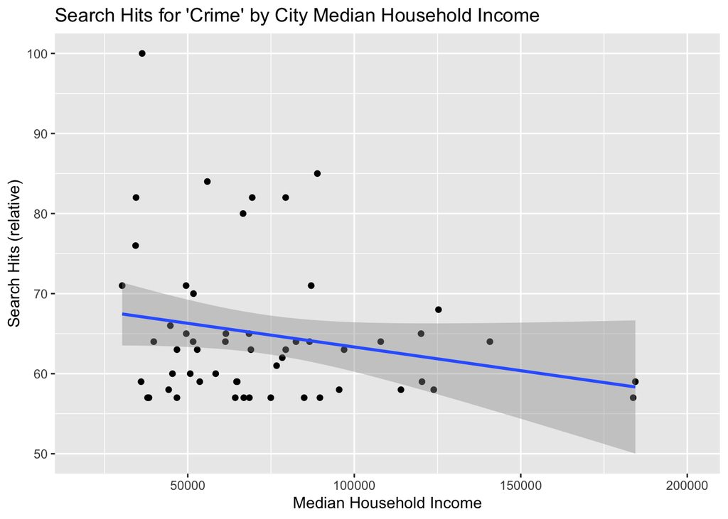

```r
qplot(hh_income, crime, data=GT_ACS1) + geom_smooth(method='lm') + xlab("Median Household Income") +
  ylab("Search Hits (relative)") + ggtitle("Search Hits for 'Crime' by City Median Household Income")
```

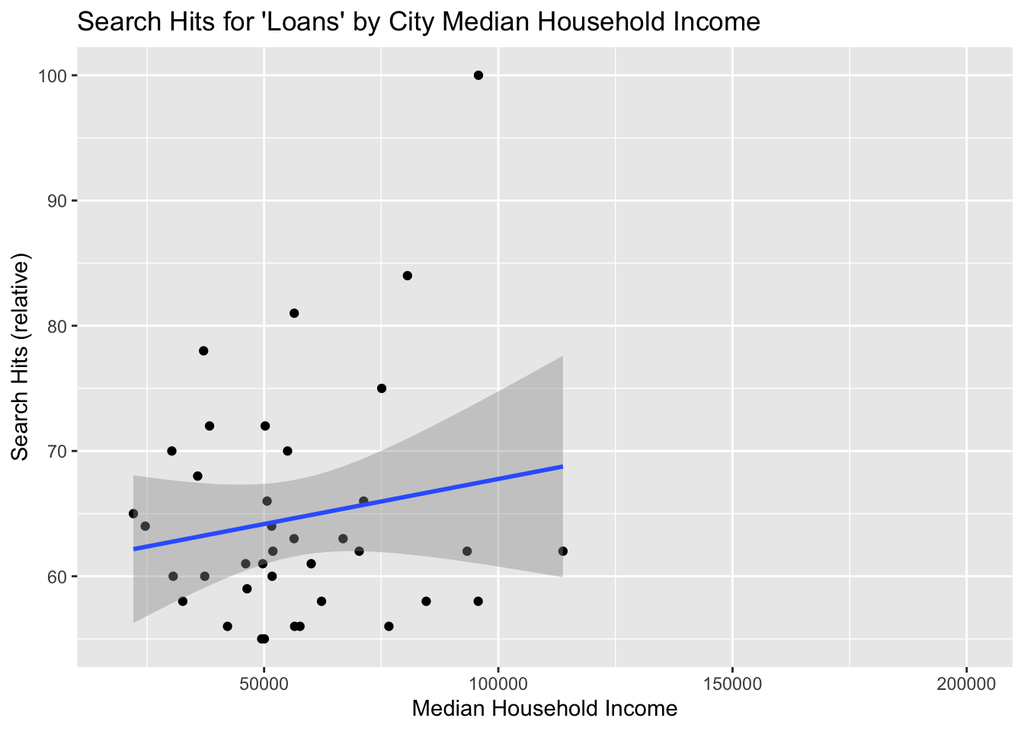

```r
qplot(hh_income, loans, data=GT_ACS1) + geom_smooth(method='lm') + xlab("Median Household Income") +
  ylab("Search Hits (relative)") + ggtitle("Search Hits for 'Loans' by City Median Household Income")
```

As household income increases, search volume for “crime” appears to decrease slightly. By contrast, as household income increases, search volune for “loans” increases.

### Repeat the above steps using the covid data and the ACS data.

```r
#merge data
GT_ACS2 <- covid_city_w %>% inner_join(acs_il, by="location")
head(GT_ACS2)
```

```
## # A tibble: 6 × 12
##   location   geo   gprop covid  mask state place NAME        pop   age hh_income
##   <chr>      <chr> <chr> <int> <int> <chr> <chr> <chr>     <dbl> <dbl>     <dbl>
## 1 Albany     US-IL web      85    NA 17    00516 Albany v…   812  41.6     72857
## 2 Algonquin  US-IL web      65    NA 17    00685 Algonqui… 30848  42.5    109819
## 3 Allenville US-IL web      80    NA 17    00867 Allenvil…   133  34.3     53611
## 4 Alton      US-IL web      NA    69 17    01114 Alton ci… 26490  38.1     43291
## 5 Altona     US-IL web      67    NA 17    01140 Altona v…   634  31.9     59583
## 6 Alvin      US-IL web      65    NA 17    01242 Alvin vi…   267  41.4     58056
## # ℹ 1 more variable: income <dbl>
```

```r
#calculate average median income
median_income <- median(GT_ACS2$hh_income, na.rm=T)

#note that the median income is not included here
GT_ACS2$income2[GT_ACS2$hh_income < median_income] <- "Below avg median HH income"
GT_ACS2$income2[GT_ACS2$hh_income > median_income] <- "Above avg median HH income"
table(GT_ACS2$income2)
```

```
##
## Above avg median HH income Below avg median HH income
##                        162                        162
```

```r
GT_ACS2 %>% summarise(covid_hits = mean(covid, na.rm=T),
                                            mask_hits = mean(mask, na.rm=T))
```

```
## # A tibble: 1 × 2
##   covid_hits mask_hits
##        <dbl>     <dbl>
## 1       70.9      70.3
```

```r
GT_ACS2 %>% group_by(income2) %>% summarise(covid_hits = mean(covid, na.rm=T),
                                            mask_hits = mean(mask, na.rm=T))
```

```
## # A tibble: 3 × 3
##   income2                    covid_hits mask_hits
##   <chr>                           <dbl>     <dbl>
## 1 Above avg median HH income       71.3      69.7
## 2 Below avg median HH income       70.2      72.6
## 3 <NA>                            NaN       NaN
```

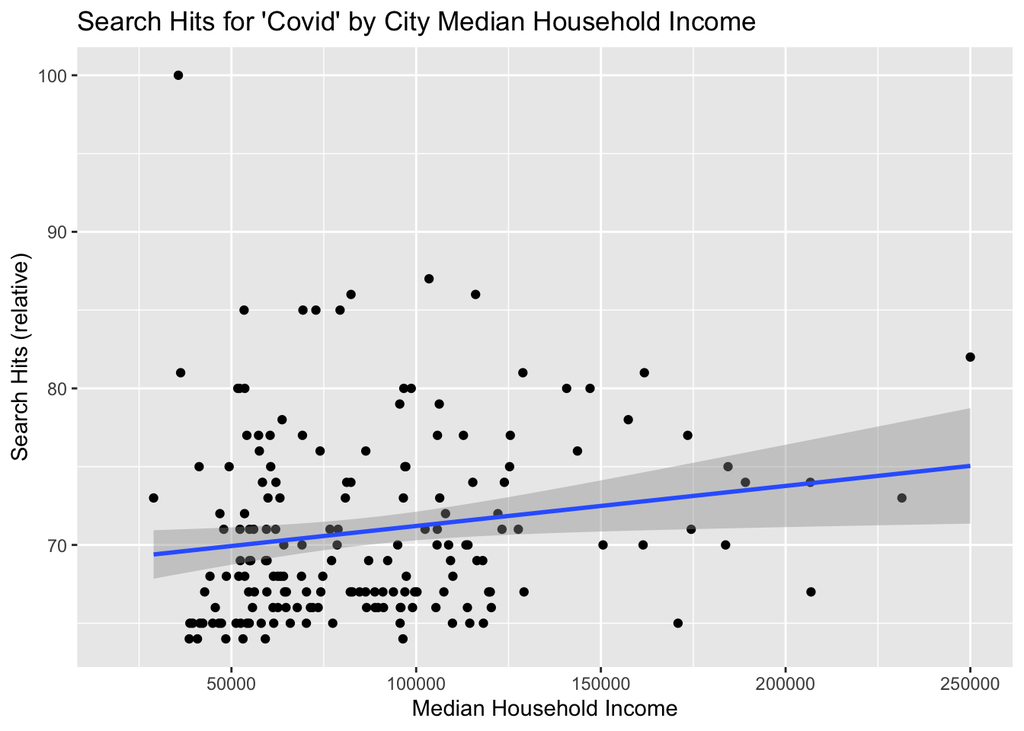

```r
qplot(hh_income, covid, data=GT_ACS2) + geom_smooth(method='lm') + xlab("Median Household Income") +
  ylab("Search Hits (relative)") + ggtitle("Search Hits for 'Covid' by City Median Household Income")
```

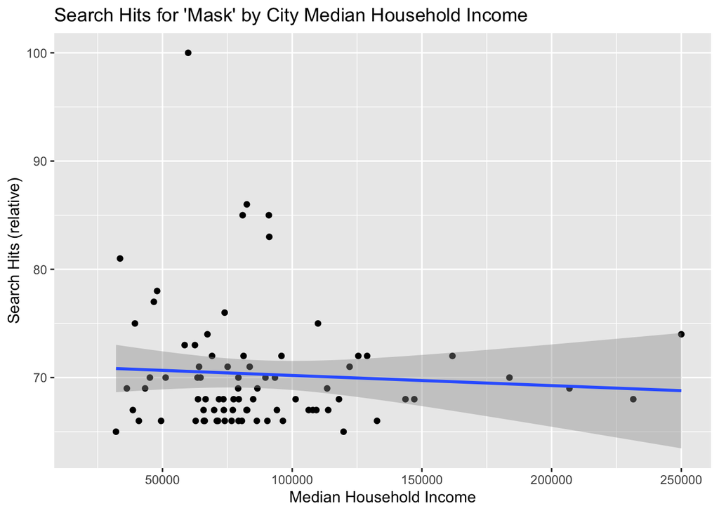

```r
qplot(hh_income, mask, data=GT_ACS2) + geom_smooth(method='lm') + xlab("Median Household Income") +
  ylab("Search Hits (relative)") + ggtitle("Search Hits for 'Mask' by City Median Household Income")
```

The search volume is quite similar between “covid” and “mask” in Illinois cities. Looking by income, there is little difference in search volume for “covid” by household income, while cities with a below average median household income are slightly more likely to have searched for “mask” than cities with an above average median household income.

In looking deeper at search trends for “covid,” it appears that as median household income increases, there is a slight increase in search volume for “covid.” The opposite is true for “mask,” where as median household income increases, there is a very slight decrease in search volume for “mask.”